# Analiza skupa podataka o kvalitetu voda

Stefan Aleksić

08. June 2023

# I Uvod

U ovom izveštaju su predstavljeni rezultati kreiranja modela za analizu kvaliteta voda u okviru država Evrope, koja je odrađena kao praktični deo ispita *Računarstvo visokih performansi u informacionom inženjeringu*.

## 1.1. Skup podataka **voda**

Skup podataka o vodama je preuzet sa sajta [eea.europa.eu](https://www.eea.europa.eu/data-and-maps/data/waterbase-water-quality-icm-2). Uz pomoć naredbe za preuzimanje *.zip* fajla i naredbe za otkapkivanje arhiviranog csv na Ubuntu OS-u.

```bash
curl -X GET  --header 'Content-Type: application/json' --header 'Accept: application/zip' https://cmshare.eea.europa.eu/s/B8dr3zPX6cyswpX/download --output data.zip

unzip data.zip /home/stefan/rvpuii-project/workspace/data
```

Ovaj skup podataka sadrži vremenske serije hranljivih materija, organske materije, opasnih materija i drugih hemikalija u rekama, jezerima, podzemnim vodama, prelaznim, priobalnim i morskim vodama. Lista identifikatora prostornih objekata sa izabranim atributima, o kojima se izveštava preko WFD (The Water Framework Directive) and [WISE Spatial data](http://dd.eionet.europa.eu/datasets/latest/WISE_SpatialData), izveštavač o prostornim podacima, dodaje se skupu podataka kao prostorna [referenca](http://dd.eionet.europa.eu/vocabulary/wise/WFDWaterBodyCategory/). Podatke je sastavila i obradila [EEA (European Environment Agency)](https://www.eea.europa.eu/). Za dodatne informacije pogledajte [metapodatke](https://docs.google.com/spreadsheets/d/1Vv_Wofjg170YPPIZKX1BCxpUb17gvs8QH5vTIoRhOdg/edit?usp=sharing).

# II Rad

## 2.1. Inicijalizacija

### 2.1.1. Preuzimanje neophodnih paketa za analizu podataka

```r
install.packages("sparklyr")
install.packages("tidyverse")
install.packages("gridExtra")
install.packages("kableExtra")
```

### 2.1.2. Uključivanje neophodnih biblioteka

```r
library(tidyr)
library(dplyr)
library(ggplot2)
library(magrittr)
library(knitr)
library(kableExtra)
library(sparklyr)
library(cowplot)
```

### 2.1.3. Instaliranje i pripremanje spark okruženja

```r
spark_install(version="3.3.2")
Sys.setenv(JAVA_HOME="/usr/lib/jvm/java-1.11.0-openjdk-amd64")
knitr::opts_knit$set(root.dir = "/home/stefan/rvpuii-project/workspace")
sc <- spark_connect(master = "local", version="3.3.2")
```

### 2.1.4. Učitavanje skupa podataka

```r
water.dataset <- spark_read_csv(sc,
                                name="waterdataset",
                                path = "/home/stefan/rvpuii-project/workspace/data/Waterbase_v2021_1_T_WISE6_AggregatedData.csv",
                                memory = T)
```

### 2.1.5. Prečišćavanje podataka

```r
water.dataset.filtered <- water.dataset %>%
  filter(!(is.na(resultQualityMeanBelowLOQ) ||
           is.na(observedPropertyDeterminandCode) ||
           is.na(resultNumberOfSamples) ||
           is.na(parameterWaterBodyCategory) ||
           is.na(resultStandardDeviationValue))) %>%
  mutate(quantified = ifelse(resultQualityMeanBelowLOQ > 0, 0, 1)) %>%
  mutate(parameterWaterBodyCategory = switch(parameterWaterBodyCategory,
                                             CW="Coastal",
                                             GW="Ground",
                                             LW="Lake",
                                             MW="Marine",
                                             RW="River",
                                             TW="Transitional",
                                             TeW="Territorial")) %>%
  select(quantified,
         parameterWaterBodyCategory,
         observedPropertyDeterminandCode,
         resultNumberOfSamples,
         resultStandardDeviationValue)
```

**Dimenzije učitanog skupa podataka: 4550583 x 31**

**Dimenzije prečišćenog skupa podataka: 2149475 x 5**

### 2.1.6. Prikaz prvih 10 redova prečišćenih podataka

| quantified | water body category | observed property determinand code | number of samples | standard deviation value |
| --- | --- | --- | --- | --- |
| 0 | River | CAS_7440-43-9 | 9 | 0.000000 |
| 0 | River | EEA_32-03-1 | 8 | 0.000000 |
| 1 | River | CAS_75-09-2 | 8 | 0.150477 |
| 0 | River | CAS_87-68-3 | 10 | 0.000000 |
| 0 | River | CAS_2310-17-0 | 8 | 0.000000 |
| 0 | River | CAS_56-23-5 | 1 | 0.000000 |
| 0 | River | CAS_465-73-6 | 8 | 0.000000 |
| 0 | River | CAS_121-75-5 | 8 | 0.000000 |
| 0 | River | CAS_56-38-2 | 8 | 0.000000 |
| 0 | River | CAS_72-20-8 | 8 | 0.000000 |

## 2.2. Klasifikacija podataka

### 2.2.1. Treniranje modela logističke regresije sa različitim vrednostima broja maksimalnih iteracija

```r
dataset.for.clustering <- sdf_random_split(water.dataset.filtered, seed=1, training=0.8, test=0.2)
formula <- quantified ~ parameterWaterBodyCategory + resultNumberOfSamples + resultStandardDeviationValue

samples <- c(1:5)
max.iterations <- samples * 5
log.reg.weighted.precision <- samples
log.reg.weighted.recall <- samples
log.reg.weighted.f.measure <- samples
log.reg.area.under.roc <- samples
log.reg.accuracy <- samples

for(i in samples){
  logreg <- ml_logistic_regression(dataset.for.clustering$training,
                                   formula,
                                   max_iter = max.iterations[i],
                                   family = "binomial")
    evaluation <- ml_evaluate(logreg, dataset=dataset.for.clustering$test)
    log.reg.weighted.precision[i] <- evaluation$weighted_precision()
    log.reg.weighted.recall[i] <- evaluation$weighted_recall()
    log.reg.weighted.f.measure[i] <- evaluation$weighted_f_measure()
    log.reg.area.under.roc[i] <- evaluation$area_under_roc()
    log.reg.accuracy[i] <- evaluation$accuracy()
}
```

### 2.2.2. Prikaz zavisnosti broja iteracija od tačnosti modela

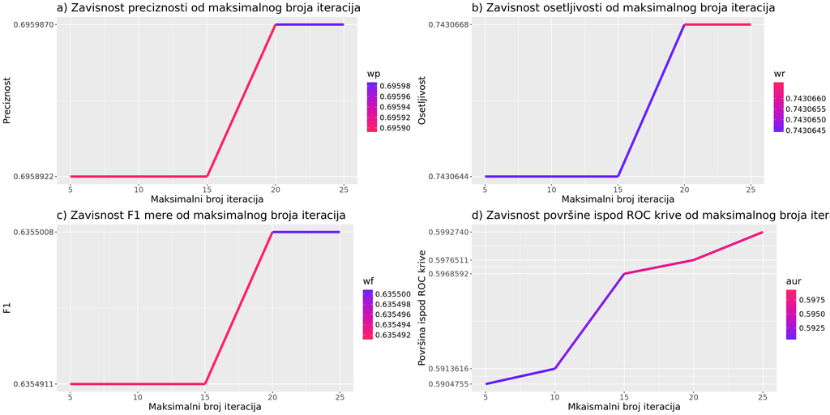

Na grafikonu **c)** je predstavljena zavisnost **F1 mere**, koja se dobija na osnovu mera **preciznosti** i **osetljivosti** i **maksimalnog broja iteracija** algoritma logističke regresije. **F1 mera**, koja se računa po obrascu $2 * Preciznost * Osetljivost / (Preciznost + Osetljivost)$, daje generalniji opis sposobnosti modela da izvrši klasifikaciju pojave, jer uzima u obzir i sposobnost da se pojava svrsta u klasu *preciznost*, kao i to da se pojava raščlani od klase **osetljivost**. Ovo je važno, jer *visoka preciznost* nema smisla, ukoliko naš model ima *nisku osetljivost* i obrnuto, jer bi se onda sve pojave svrstale, ili odbacile kao instance posmatrane klase.

### 2.2.3. Tačnost različitih klasifikacionih modela u odnosu na metod testiranja modela

```r
formula <- quantified ~ parameterWaterBodyCategory + resultNumberOfSamples + resultStandardDeviationValue

# Validacioni skup
dataset.for.validation <- sdf_random_split(water.dataset.filtered, seed=1, training=0.8, test=0.2)

bayes.model <- dataset.for.validation$training %>%
  ml_naive_bayes(formula)

linear.svc.model <- dataset.for.validation$training %>%
  ml_linear_svc(formula)

decision.tree.classifier <- dataset.for.validation$training %>%
  ml_decision_tree_classifier(formula)

bm.vs.accuracy <- ml_evaluate(bayes.model, dataset.for.validation$test)$Accuracy
svcm.vs.accuracy <- ml_evaluate(linear.svc.model, dataset.for.validation$test)$Accuracy
d3m.vs.accuracy <- ml_evaluate(decision.tree.classifier, dataset.for.validation$test)$Accuracy

# 4-trostruko ukrstanje
k.cross.fold.4 <- function(filtered.dataset, model, formula){
  dataset <- filtered.dataset %>%
    sdf_random_split(seed=1,
                     s1=0.25,
                     s2=0.25,
                     s3=0.25,
                     s4=0.25)
  training <- list(
    s1 = sdf_bind_rows(dataset$s2, dataset$s3, dataset$s4),
    s2 = sdf_bind_rows(dataset$s1, dataset$s3, dataset$s4),
    s3 = sdf_bind_rows(dataset$s1, dataset$s2, dataset$s4),
    s4 = sdf_bind_rows(dataset$s1, dataset$s2, dataset$s3)
  )

  trained = list(s1=model(training$s1, formula),
                 s2=model(training$s2, formula),
                 s3=model(training$s3, formula),
                 s4=model(training$s4, formula)
  )

  model.accuracy <- (ml_evaluate(trained$s1, dataset$s1)$Accuracy +
                       ml_evaluate(trained$s2, dataset$s2)$Accuracy +
                       ml_evaluate(trained$s3, dataset$s3)$Accuracy +
                       ml_evaluate(trained$s4, dataset$s4)$Accuracy
  ) / 4
}

bayes.model.4.fold.accuracy <- k.cross.fold.4(water.dataset.filtered, ml_naive_bayes, formula)
svc.4.fold.accuracy <- k.cross.fold.4(water.dataset.filtered, ml_linear_svc, formula)
d3.4.fold.accuracy <- k.cross.fold.4(water.dataset.filtered, ml_decision_tree_classifier, formula)
```

### 2.2.4. Tabelarni prikaz tačnosti različitih klasifikacionih modela u odnosu na metod testiranja modela

[output not shown]

U ovoj tabeli je prikazano poređenje performansi različitih klasifikacionih modela, koji su trenirani sa istim prediktorskim i ciljnim obeležjem, nad istim podacima i sa istim parametrima. Može se primetiti da je model klasifikacije koji se zasniva na stablu odlučivanja daleko tačniji u odnosu na naivni Bayes-ov model, ili model mašine potpornih vektora.

## 2.3. Klasterizacija podataka

### 2.3.1. Prečišćenih podataka za proces klasterizacije

```r
dataset.for.clusterisation <- water.dataset.filtered %>%
  select(parameterWaterBodyCategory, resultNumberOfSamples, quantified)

dataset.for.clusterisation.summary <- dataset.for.clusterisation %>%
  group_by(parameterWaterBodyCategory) %>%
  summarize(count = n(), meanNumberOfSamples = mean(resultNumberOfSamples), stdev = sd(resultNumberOfSamples), quantified = avg(quantified)) %>% collect
```

### 2.3.2. Prikaz prečišćenih podataka

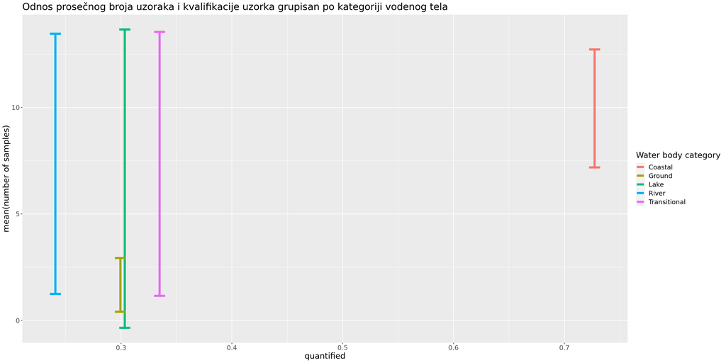

Na ovom grafikonu je ilustrovan *prečišćeni skup podataka* koji će se nastavku iskoristiti za proces *klasterizacije*. Ovaj skup podataka je grupisan na osnovu **kategorije vodenog tela** čiji se uzorak analizira, a grafikon predstavlja odnos **prosečnog broja uzoraka kategorije vodenog tela** i **indikatora kvalifikacije određene kategorije vodenog tela**. Na grafikonu možemo videti da je standardna devijacija prosečnog broja uzoraka za reke, jezera i protočne vode mnogo veća u odnosu na podzemne vode (koje nemaju velike oscilacije u broju uzoraka, ali u porseku imaju mnogo manji broj uzoraka), kao i priobalne vode, koje imaju izuzettno veliki broj kvalifikovanih voda, kao i prosečan broj odmerenih uzoraka.

### 2.3.3. Metod k-means

```r
formula.clusterisation <- parameterWaterBodyCategory ~ resultNumberOfSamples + quantified

model.5   <- ml_kmeans(dataset.for.clusterisation, formula.clusterisation, seed = 1, k = 5)
model.10  <- ml_kmeans(dataset.for.clusterisation, formula.clusterisation, seed = 1, k = 10)
model.15  <- ml_kmeans(dataset.for.clusterisation, formula.clusterisation, seed = 1, k = 15)
model.20  <- ml_kmeans(dataset.for.clusterisation, formula.clusterisation, seed = 1, k = 20)
```

### 2.3.4. Prikaz centroida klastera u odnosu na broj klastera K

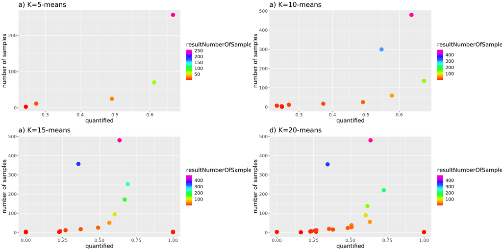

Na grafikonu **a)** je ilustrovana prostorna pozicija centroida $5$ izdvojenih klastera u okviru algoritma za klasterizaciju k-means. Možemo uočiti da su se $4/5$ klastora formirala u oblasti koja ima relativno mali broj uzoraka i da su ti uzorci prevashodno manjeg kvaliteta, u odnosu na $5.$ klaster, koji ima dosta uzoraka, koji su zadovoljavajućeg kvaliteta. Ovim možemo da zaključimo da je skup podatak voda koje su se analizirale testirao nad nekvalifikovanih u mnogo manjoj meri, odnosno sa mnogo manje uzoraka.

Na grafikovnu **b)** možemo identifikovati pozicije $10$ centroida klastera na *2-D* grafikonu. U ovom slučaju možemo uočiti prethodno identifikovani trend, da je dosta pojava bilo sa mnogo malom vrednošću brojnosti testiranih uzoraka, kao i to da pojave koje imaju veći broj uzoraka se nalaze na delu zadovoljavajućeg kvaliteta.

Na grafikonu **c)**, na kome su identifikovane pozicije $15$ centroida različitih klastera na *2-D* grafikonu odnosa broja uzoraka i kvaliteta vodene kategorije, se može čak i uočiti naizgled oblik grafika eksponencijalne funkcije, čiji broj uzoraka raste sa porastom kvaliteta uzoraka, sa još $3$ centroida klastera koji se nalaze na pojedinim ekstremnim granicama grafikona.

Na poslednjem, **d)** grafikonu, koji takođe ilustruje položaj centroida, u ovom slučaju $20$ klastera na grafikonu odnosa broja uzoraka i njihovih kvaliteta, sve se jasnije vidi trend u rastu broja uzoraka sa kvalitetom kategorije vodenog tela. Opet i ovde postoje izdvojeni klasteri koji se nalaze na pozicijama graničnih vrednosti jednog od predikatora.

## 2.4. Zatvaranje spark konekcije

```r
spark_disconnect(sc)
```

# III Zaključak

Ovaj rad je imao za cilj upoznavanje sa programskim jezikom *R*, njegovim stilom programiranja, bibliotekama koje su na raspolaganju, sa najvećim osvrtom na **sparklyr** koja se koristi u kontekstu analize velikih skupova podataka. Fokus ovog rada nije bio preterano na sam skup podataka i informacije koje se iz njega mogu izvući, već na sam postupak analize podataka, kroz njihovo prečišćavanje, transformisanje, obradu i vizuelizaciju informacija koje su iz njih izvučene.

Iz ovog rada se moglo ustanoviti da je važno upoznati se sa dostupnim algoritmima za klasifikaciju i klasterizaciju podataka, tipovima podataka nad kojima su najefikasniji, a najvažnije od svega, performansama koje oni ostvaruju u zavisnosti od korišćenih parametara i testova koji se nad njima primenjuju u cilju njihove validacije. Na osnovu onoga što je u radu izloženo, maksimalan broj iteracija koji treba ciljati pri klasifikaciji je $20$. Što se testova za procenu tačnosti nad validacionom skupom tiče, pristup validacionog skupa i k-tostruka validacija ukrštanjem daju poprilično slične rezultate, barem za parametar $k=4$, pa bih samim tim pre koristio pristup validacionog skupa, jer je mnogo lakši za primenu.

Klasterizacija nad ovim skupom podataka nije prikazala neke znatne razlike za iskorišćene parametre u algoritmu **k-means**. Trend koji se izvukao iz podataka je mogao da se uvidi još nad klasterizacijom od $k=10$ klastera. Na kraju, što se samih klasifikacionih modela tiče, model stabla odlučivanja je za ovaj skup podataka dao najbolju tačnost, te bih njega iskoristio nad ovako sličnim podacima, no, to naravno ne mora biti slučaj u nekom drugom kontekstu.

Zaključujem da je bitno upoznati se sa skupom podataka koji se analizira i na osnovu njegove manje particije ispitati performanse modela za klasifikaciju i kalsterizaciju za koje naslućujemo da bi bili pogodni, kako bi imali i potvrdu da je isplativo upotrebiti ih nad konkretnim skupom podatka u celini. Ne treba smatrati da će svaki model dati iste performanse, ne osvrćući se na njegove parametre i validirati ga uvek na isti način, već u skladu sa prirodom podataka koje je potrebno analizirati, uskladiti ove stavke pogodno.